# Entering, Coding, and Analyzing Qualitative Data

GE2021 Research Technology, Fall 2026

Chad (Chungil Chae)

cchae@kean.edu

Wed, 16 September 2026

# Learning Objectives

- 12-1 Describe how to enter, clean, and organize qualitative data.
- 12-2 Examine and code raw data.
- 12-3 Analyze qualitative data.

## SHORT VIDEO INTRODUCTION

[video not shown]

# Enter, Clean, and Organize Qualitative Data

## Transcription

- Transcribing: the process where the recording of an interview or a focus group or any other recorded material is turned into written words.
- There are various dictation applications and software that can help with transcription process.
- A researcher needs to include everything that is heard, from grammatical errors and mispronunciations to background noise.

## Memoing

- Taking notes on what you are thinking as you read and reread the transcribed interviews is called memoing, which facilitates later analysis by bringing you closer to the written material.
- The researcher relies on these memos or written impressions that were collected during the analysis to see for consistencies or repeated thoughts and ideas.
- Classification of memos is a process that happens after the memos are written in free-thinking style.
  - **Theoretical memos:** These memos relate to a theory or make connections between the narrative and theoretical concepts.
  - **Self-reflection memos:** These memos connect the narrative with past experiences or simply note how the researcher perceives the written information.
  - **Hypothetical memos:** These memos propose or predict a relationship between different parts of the narrative, though it is still too early to come to a conclusion.

## Diagrams

- Diagrams are not only useful for record keeping but can also lend a systematic and organized view of the data.
- Various software programs allow researchers to create a range of diagrams, from simple to complex.

[figure not shown]

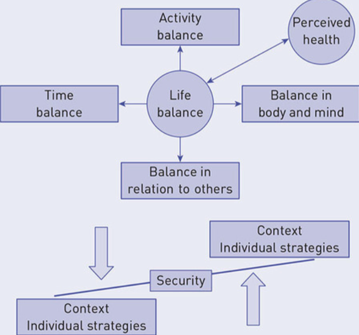